# Thinking Aloud

```r
#Play the above chunk and this one in your Console to access the data
View(Baumann)
?Baumann
```

## Background

Thinking aloud is known to be beneficial, but is there a method that works better than traditional instruction? A study was performed to 4th graders in the midwestern United States testing three different instructional methods to see if students improved after each method was implemented. Details of the study are shown below.

“The [empirical] background for the experiment draws from research on comprehension [monitoring] and the [think aloud] procedure.”

“This study investigated the effectiveness of explicit instruction in ‘think aloud’ as a means to promote elementary students’ comprehension monitoring abilities” [(Baumann & Jones, 1992)](http://jlr.sagepub.com/content/24/2/143.full.pdf).

Details of the Study (click to view)

### Question and Hypotheses

The significance level will be set at

$$\alpha = 0.05$$

Since it is more affective to measure the pretest against the post test, a Kruskal-Wallis Test will be performed to analyze the differences between the post and pre test of the second test.

Question (click to view)

## Analysis

All three of the instructional methods were compared.

- Basal: Standard teaching method
- DRTA: Directed Reading Thinking Aloud
- Strat: Another innovative method

A Kruskal-Wallis test was conducted. See below for the results.

```r
pander(kruskal.test(Difference2 ~ group, data=Baumann))
```

Kruskal-Wallis rank sum test: `Difference2` by `group`

| Test statistic | df | P value |
| --- | --- | --- |
| 15.45 | 2 | 0.0004406 * * * |

This pirate plot below shows a comparison of the hypotheses to the instructional methods: Basal, DRTA, and Strat.

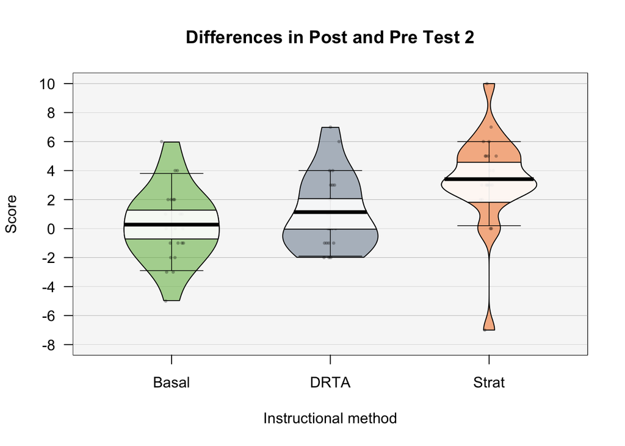

```r
pirateplot(formula = Difference2 ~ group,
          data = Baumann,
          theme = 3,
          pal = "appletv",
          bean.f.o = .5,
          back.col = grey(.97),
          quant = c(.1, .9), # 10th and 90th quantiles
          quant.col = "black", # Black quantile lines
          main = "Differences in Post and Pre Test 2",
          xlab = "Instructional method",
          ylab = "Score")
```

This 5 number summary below represents the distribution of the three instructional methods.

```r
pander(favstats(Difference2 ~ group, data=Baumann))
```

| group | min | Q1 | median | Q3 | max | mean | sd | n | missing |
| --- | --- | --- | --- | --- | --- | --- | --- | --- | --- |
| Basal | -5 | -1 | 0 | 2 | 6 | 0.2727 | 2.585 | 22 | 0 |
| DRTA | -2 | -1 | 0 | 3 | 7 | 1.136 | 2.587 | 22 | 0 |
| Strat | -7 | 3 | 3 | 5 | 10 | 3.409 | 3.217 | 22 | 0 |

### Results of the Test

Comparing instructional methods, there is sufficient evidence to conclude at least one of the instructional methods is different from the others.

## Interpretation

The pirate plot demonstrates one of the instructional methods is different (infering the Strat method) and is confirmed by the five number summary showing Basal and DRTA’s median as 0 and Strat’s median as 3. This confirms the alternative hypothesis that at least one of the instructional methods is different from the others.

### Conclusion

In addition to the interpretation, there are also a few concepts to consider. For each instructional method, there were only 22 participants for each, which is a small sample size. It would be valuable to perform another test to check consistency by increasing the sample size of each instructional method.

Also important to note, the post test had three more questions added to it then the pre test. Ideally it would be best to keep the amount of questions the same for consistency.

There are possibly multiple ways to enhance thinking aloud in students. Further testing would be beneficial in confirming the validity of the tests.